# Decision Trees and Random Forest

BIOMEDE 499 - AI in BME

Last modified: November 27, 2020

# 1 Decision Trees

In this lesson, we will apply decision trees to predict patient health outcome from the Framingham dataset. To accomplish this, we will be using the `rpart` library, which implements classification and regresssion trees.

In this demonstration, we will attempt to predict the occurrence of diabetes. First, let’s read in the Framingham dataset and remove rows with missing values. We will also subset out temporal variables for simplicity’s sake.

```r
fram = readxl::read_excel("frmgham2.xls")
# identify rows missing any values
missing_vals = apply(fram, MARGIN = 1, function(x){return(any(is.na(x)))})
# extract rows without missing values and non-time columns
fram = fram[!missing_vals,1:31]
# ensure output variable to be categorical
fram$DIABETES = as.factor(fram$DIABETES)
```

To build the model, we use the `rpart` function, which takes a formula, a source data frame, and a method. The formula `DIABETES ~ .` represents diabetes a function of all other features. For classification, method should equal `"class"`.

```r
library(rpart) # load rpart
# generate a classification model
diab_model = rpart(DIABETES ~ ., data = fram, method = "class")
```

We can view details of our model, including the relative error by number of splits, the importance of variables, and information on the tree structure itself using the `summary` function.

```r
summary(diab_model)
```

```
## Call:
## rpart(formula = DIABETES ~ ., data = fram, method = "class")
##   n= 2236
##
##           CP nsplit rel error    xerror       xstd
## 1 0.25316456      0 1.0000000 1.0000000 0.07669346
## 2 0.02215190      1 0.7468354 0.7848101 0.06849594
## 3 0.01265823      3 0.7025316 0.7594937 0.06744589
## 4 0.01000000      6 0.6645570 0.7848101 0.06849594
##
## Variable importance
##  GLUCOSE      BMI     HDLC     LDLC      CVD  MI_FCHD HEARTRTE   ANYCHD
##       71        7        3        3        3        2        1        1
##  TOTCHOL   HOSPMI   STROKE      AGE   RANDID    SYSBP  PREVCHD
##        1        1        1        1        1        1        1
##
## Node number 1: 2236 observations,    complexity param=0.2531646
##   predicted class=0  expected loss=0.0706619  P(node) =1
##     class counts:  2078   158
##    probabilities: 0.929 0.071
##   left son=2 (2164 obs) right son=3 (72 obs)
##   Primary splits:
##       GLUCOSE < 140.5   to the left,  improve=74.397480, (0 missing)
##       DEATH   < 0.5     to the left,  improve= 9.800571, (0 missing)
##       CVD     < 0.5     to the left,  improve= 8.004126, (0 missing)
##       MI_FCHD < 0.5     to the left,  improve= 6.485865, (0 missing)
##       SYSBP   < 154.75  to the left,  improve= 6.130076, (0 missing)
##
## Node number 2: 2164 observations,    complexity param=0.01265823
##   predicted class=0  expected loss=0.04713494  P(node) =0.9677996
##     class counts:  2062   102
##    probabilities: 0.953 0.047
##   left son=4 (1675 obs) right son=5 (489 obs)
##   Primary splits:
##       CVD     < 0.5     to the left,  improve=3.558544, (0 missing)
##       DEATH   < 0.5     to the left,  improve=3.302397, (0 missing)
##       GLUCOSE < 100.5   to the left,  improve=3.277967, (0 missing)
##       ANYCHD  < 0.5     to the left,  improve=2.495379, (0 missing)
##       MI_FCHD < 0.5     to the left,  improve=2.237395, (0 missing)
##   Surrogate splits:
```

[output cut: 86 more lines]

```
##
## Node number 13: 16 observations
##   predicted class=1  expected loss=0.3125  P(node) =0.007155635
##     class counts:     5    11
##    probabilities: 0.312 0.688
##
## Node number 22: 59 observations
##   predicted class=0  expected loss=0.1694915  P(node) =0.0263864
##     class counts:    49    10
##    probabilities: 0.831 0.169
##
## Node number 23: 8 observations
##   predicted class=1  expected loss=0.125  P(node) =0.003577818
##     class counts:     1     7
##    probabilities: 0.125 0.875
```

This returns a lot of information, including

- the error for different tree complexities
- scores for variable importance
- information about each node
  - the number of observations used to train the node
  - the probability a sample will be categorized by the node
  - the probability of the splits at the node if not a leaf

To return subsets of this information, we can use other functions encapsulated in the package.

We can also read a brief description of the tree’s structure with the `print` function.

```r
print(diab_model)
```

```
## n= 2236
##
## node), split, n, loss, yval, (yprob)
##       * denotes terminal node
##
##  1) root 2236 158 0 (0.92933810 0.07066190)
##    2) GLUCOSE< 140.5 2164 102 0 (0.95286506 0.04713494)
##      4) CVD< 0.5 1675  53 0 (0.96835821 0.03164179) *
##      5) CVD>=0.5 489  49 0 (0.89979550 0.10020450)
##       10) LDLC>=139.5 422  32 0 (0.92417062 0.07582938) *
##       11) LDLC< 139.5 67  17 0 (0.74626866 0.25373134)
##         22) BMI< 30.705 59  10 0 (0.83050847 0.16949153) *
##         23) BMI>=30.705 8   1 1 (0.12500000 0.87500000) *
##    3) GLUCOSE>=140.5 72  16 1 (0.22222222 0.77777778)
##      6) GLUCOSE< 163 25  12 0 (0.52000000 0.48000000)
##       12) HDLC>=44.5 9   1 0 (0.88888889 0.11111111) *
##       13) HDLC< 44.5 16   5 1 (0.31250000 0.68750000) *
##      7) GLUCOSE>=163 47   3 1 (0.06382979 0.93617021) *
```

It returns a nested list of splits, with information on the total number of samples used and categorized from the training data. This can be helpful for quickly assessing the evennessof splits.

Or we can generate a visual representation of the tree by sequentially calling `plot` and `text`.

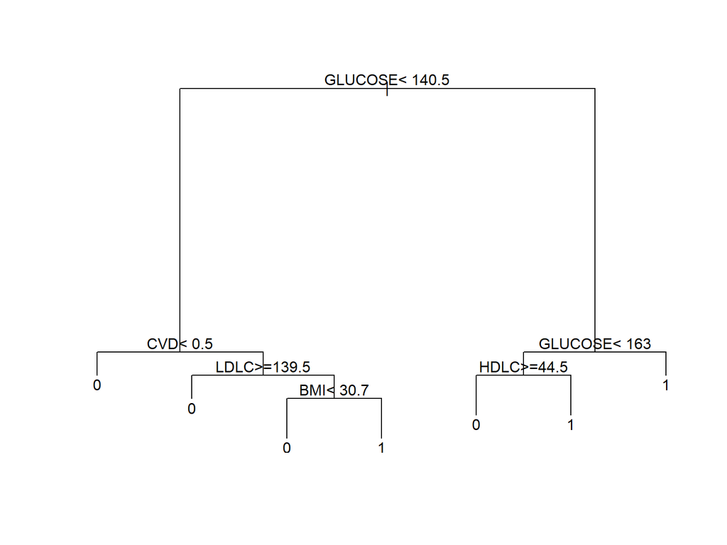

```r
plot(diab_model) # generate plot
text(diab_model) # include text annotation
```

## 1.1 Question: Can you interpret the generated tree model? What do the interpolated splits tell you about diabetes occurance? Do the splits and leaves make sense?

We may want to calculate the **resubstitution error**, which *quantifies the accuracy of the model* on the training data. Though a built-in function is not provided, we can determine this easily as shown next.

```r
# predict diabetes outcome using the model we built
pred_diab = predict(diab_model, fram, type = "class")
# resutbstitution error = fraction of predictions that are not equal
resub_error = mean(pred_diab != fram$DIABETES)
resub_error
```

```
## [1] 0.04695886
```

To find cross-validation error, we view the `cptable` element of the `diab_model` object. The `xerror` column refers to the cross-validation error (default k = 10).

```r
diab_model[["cptable"]]
```

```
##           CP nsplit rel error    xerror       xstd
## 1 0.25316456      0 1.0000000 1.0000000 0.07669346
## 2 0.02215190      1 0.7468354 0.7848101 0.06849594
## 3 0.01265823      3 0.7025316 0.7594937 0.06744589
## 4 0.01000000      6 0.6645570 0.7848101 0.06849594
```

We can change the number of folds by passing the `part.control` function with its `xval` parameter equal to the number of folds to the `control` parameter of the `rpart` function. We’ll touch on `control` soon.

```r
# specify cross-validation fold to be 5
control_args = rpart.control(xval = 5)
diab_model_k_5 = rpart(DIABETES ~ ., data = fram, method = "class",
                       control = control_args)
```

We can also (manually) calculate the cross-validation error.

```r
K = 10 # define the number of folds
errors = c() # create a variable to store error values in
folds = rep_len(1:K, nrow(fram)) # generate a vector matching samples to a fold
# permute the original vector to retain equal counts but randomize the order
folds = sample(folds, nrow(fram), replace = FALSE)
for(k in 1:K){ # for each fold
  # build the model using the subset of data outside of the fold
  model = rpart(DIABETES ~ ., data = fram[folds != k,], method = "class")
  # predict the output for the fold
  prediction = predict(model, fram[folds == k, ], type = "class")
  # calcuate the error
  errors = c(errors, mean(prediction != fram$DIABETES[folds == k]))
}
mean(errors) # average error across all folds
```

```
## [1] 0.05590967
```

To prune the tree, we first want to determine the optimal complexity parameter. We can view a heuristic of complexity parameter versus cross-validation error with the `plotcp` function. The bottom x axis represents the `cp` value while the top shows the number of leaves at that complexity.

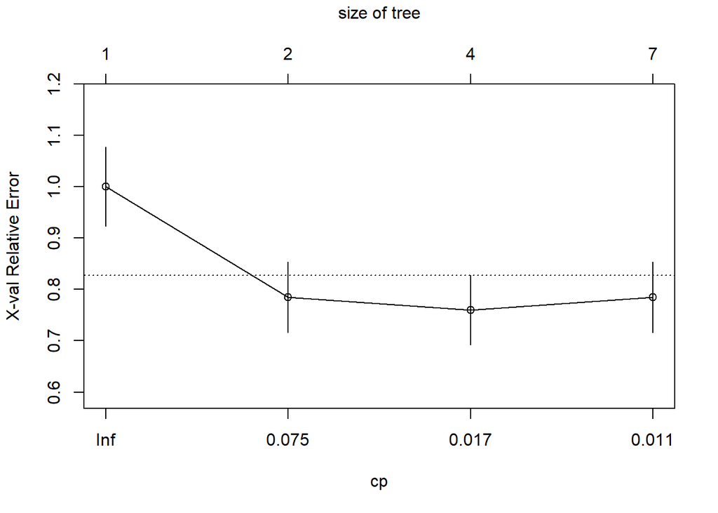

```r
plotcp(diab_model, upper = "size");
```

## 1.2 Question: Why might we choose a model that doesn’t have the lowest error? In what cases would you expect a simpler model to have better performance?

The plot above shows that the decrease in error is minimal past `cp = 0.017`. Based on this information, we could apply the `prune` function to prune our model at this cp value.

```r
pruned_diab_model = prune(diab_model, cp = 0.017)
```

We see that this new model makes decisions based off of three splits:

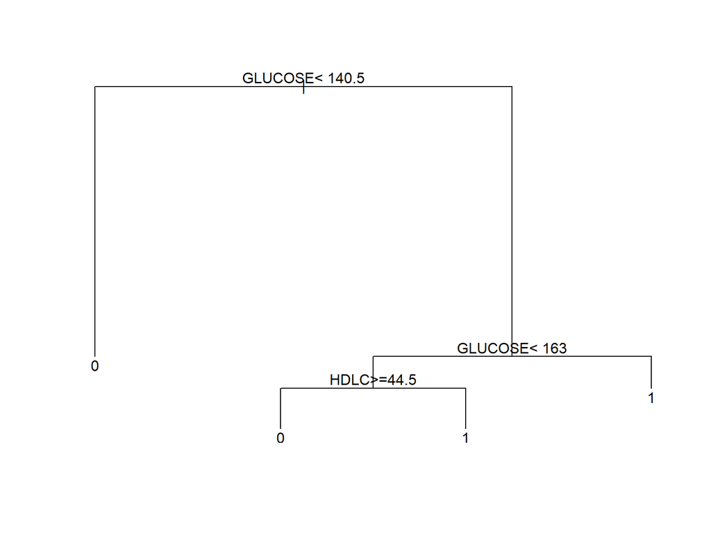

```r
plot(pruned_diab_model)
text(pruned_diab_model)
```

Finally, to assess the results of this model, let’s generate a confusion matrix. There isn’t a built-in function for this, but we can easily compute the values for the two output labels (0 vs. 1) that we have.

```r
pred_diab_pruned = predict(pruned_diab_model, fram, type = "class")
confusion_mat = matrix(c(
  sum(pred_diab_pruned == fram$DIABETES & pred_diab_pruned == 1), # true positive
  sum(pred_diab_pruned != fram$DIABETES & pred_diab_pruned == 1), # false positive
  sum(pred_diab_pruned != fram$DIABETES & pred_diab_pruned == 0), # false negative
  sum(pred_diab_pruned == fram$DIABETES & pred_diab_pruned == 0) # true negative
  ), nrow = 2)
confusion_mat
```

```
##      [,1] [,2]
## [1,]   55  103
## [2,]    8 2070
```

Let’s also try this for the original model to compare the differences in predictions.

```r
confusion_mat = matrix(c(
  sum(pred_diab == fram$DIABETES & pred_diab == 1), # true positive
  sum(pred_diab != fram$DIABETES & pred_diab == 1), # false positive
  sum(pred_diab != fram$DIABETES & pred_diab == 0), # false negative
  sum(pred_diab == fram$DIABETES & pred_diab == 0) # true negative
  ), nrow = 2)
confusion_mat
```

```
##      [,1] [,2]
## [1,]   62   96
## [2,]    9 2069
```

## 1.3 Note

When you grow a decision tree, consider its *simplicity* and *predictive power*. A deep tree with many leaves is usually highly accurate on the training data. However, the tree is not guaranteed to show a comparable accuracy on an independent test set. A leafy tree tends to **overtrain** (or overfit), and its test accuracy is often far less than its training (resubstitution) accuracy. In contrast, a shallow tree does not attain as high of a training accuracy. But a shallow tree can be more genralizable — its training accuracy could be close to that of a representative test set. Also, a shallow tree is easier to interpret. If you do not have enough data for training and testing, estimate tree accuracy by **cross-validation**.

# 2 Random Forest

Now, let’s try a similar task using a Random Forest model instead. The `randomForest` package implements the algorithm in R.

```r
library(randomForest)
```

We can then build the model using the `randomForest` function. For this example, we will predict occurance of stroke from the Framingham dataset. Note that the function attempts to infer if regression or classification should be completed, so the desired response variable should be converted to a factor before running the function.

```r
fram$STROKE = as.factor(fram$STROKE)
stroke_model_rf = randomForest(STROKE ~ ., data = fram, importance = TRUE)
```

The `randomForest` function also takes several hyperparameters, including:

- `ntree` - the number of trees to include in the ensemble (default = 500)
- `mtry` - the number of features to randomly use at each split (default = sqrt(number of features))
- `maxnodes` - the maximum number of leaves in a tree
- `nodesize` - the minimum size of a leaf

To gerate basic information about the model, use the `print` function:

```r
print(stroke_model_rf)
```

```
##
## Call:
##  randomForest(formula = STROKE ~ ., data = fram, importance = TRUE)
##                Type of random forest: classification
##                      Number of trees: 500
## No. of variables tried at each split: 5
##
##         OOB estimate of  error rate: 2.42%
## Confusion matrix:
##      0   1 class.error
## 0 2050   0   0.0000000
## 1   54 132   0.2903226
```

To determine the **out-of-bag** (OOB) error of the model, we look at the final element in the `OOB` column of the `err.rate` element of the model object.

```r
stroke_model_rf$err.rate[500, "OOB"]
```

```
##        OOB
## 0.02415027
```

Let’s also assess the resubstitution error. Just like with `rpart`, we can pass our model as a parameter to the `predict` function.

```r
pred_stroke = predict(stroke_model_rf, fram)
# fraction of predictions that are not equal to true label
resub_error = mean(pred_stroke != fram$STROKE)
resub_error
```

```
## [1] 0
```

The `importance` function determines the importance of features using both mean decrease in **accuracy** and mean decrease in **Gini coefficient**:

```r
stroke_imp = as.data.frame(importance(stroke_model_rf))
stroke_imp[order(stroke_imp$MeanDecreaseGini, decreasing=TRUE), ]
```

```
##                    0           1 MeanDecreaseAccuracy MeanDecreaseGini
## CVD      47.18901297 52.37829503           50.7939778       66.5980677
## PREVSTRK 24.33607859 35.31218300           31.4890819       39.5861201
## ANYCHD   25.93910927 -1.61554418           27.4929106       37.7270973
## AGE      -1.28447776  8.71736336            4.3803477       16.2303961
## SYSBP     3.77256902  3.29510224            4.9174065       14.4073218
## MI_FCHD  18.81532283  2.61107349           19.4528426       13.9732388
## DIABP     3.81393752  1.60549216            4.1220801       12.8589805
## TOTCHOL   4.20156358  0.02527422            3.9809581       12.7690856
## GLUCOSE   4.31326431  1.13398660            4.4297385       12.7615284
## TIME     -0.49739943 -0.14255728           -0.5093629       12.3264123
## BMI       2.80088416 -1.91957294            1.6449069       12.1440916
## LDLC      3.68890420 -0.19763079            3.4924756       11.9686292
## RANDID   -0.99571054 -1.36674512           -1.5060426       11.7978974
## HEARTRTE  1.10643973 -0.60571176            0.6239026       11.0763136
## HDLC      2.76981328 -1.67234993            1.9018778       11.0605725
## DEATH     6.49337364 -0.05664437            5.3621119        6.1454072
## CIGPDAY   5.74278877 -1.74486976            4.6166664        4.5746826
## educ      3.44460571 -0.96397618            2.6070826        4.3884382
## HOSPMI    5.67892915  5.57775623            7.2822106        4.2459473
## ANGINA    2.01238206  7.29917776            6.2624447        4.0149702
## PREVCHD   0.09039822  5.60871751            2.8883595        3.2056903
## BPMEDS    1.51959442 -0.86028272            1.0863649        2.4483624
## PREVAP   -1.59336132  3.85059644            0.1747109        2.2625021
## SEX       5.51981985 -2.43777625            4.0921010        2.1554978
## PREVMI    5.85867312  0.73516338            5.8385916        2.0910543
## DIABETES  0.49870007  0.74701301            0.8208772        2.0460414
## PREVHYP  -0.25159695  7.28827028            4.7372930        2.0372088
## CURSMOKE  3.12455844 -1.49313930            1.9929516        1.8907467
## HYPERTEN -2.79948508  5.72156345            1.4647097        0.9375603
## PERIOD    0.00000000  0.00000000            0.0000000        0.0000000
```

The Gini Coefficient takes a value between 0 and 1 and measures both the accuracy and diffusion of classifications, with 0 representing perfect classification, 1 a perfectly random distribution. The algorithm used in `randomForest` minimizes the Gini Coefficient.

We can also visualize importance with the `varImpPlot` function.

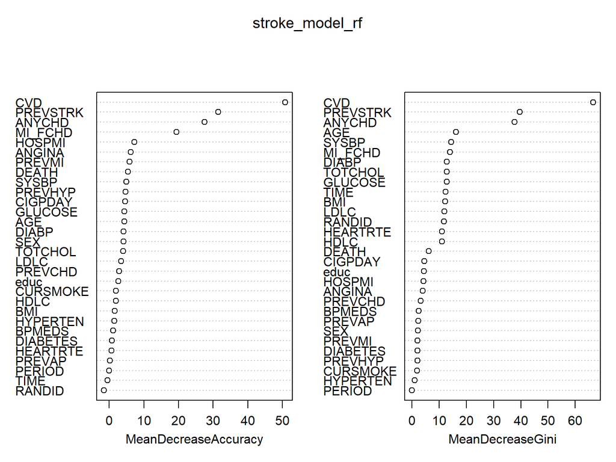

```r
varImpPlot(stroke_model_rf)
```

What if an ensemble needs more trees? We can use the `grow` function to add an arbitrary number of trees.

```r
stroke_model_rf_500 = grow(stroke_model_rf, 500)
```

Let’s assess the accuracy of the expanded ensemble using a confusion matrix

```r
pred_stroke_500 = predict(stroke_model_rf_500, fram, type = "class")
confusion_mat = matrix(c(
  sum(pred_stroke_500 == fram$STROKE & pred_stroke_500 == 1), # true positive
  sum(pred_stroke_500 != fram$STROKE & pred_stroke_500 == 1), # false positive
  sum(pred_stroke_500 != fram$STROKE & pred_stroke_500 == 0), # false negative
  sum(pred_stroke_500 == fram$STROKE & pred_stroke_500 == 0) # true negative
  ), nrow = 2)
confusion_mat
```

```
##      [,1] [,2]
## [1,]  186    0
## [2,]    0 2050
```

# 3 Function glossary

- `matrix` - converts the arguments into a matrix
- `rep_len` - generates a vector with equal to the second parameter by repeating the first argument